# Modul 1: Analisis Survei Kepuasan Pelanggan (SERVQUAL)

Immantaka Juniarsa

05 November 2026

```r
suppressPackageStartupMessages({
  library(dplyr); library(tidyr); library(ggplot2); library(psych); library(MASS)
})
# dplyr::select tertutup oleh MASS::select, jadi dipanggil eksplisit di bawah
source("R/plot_theme.R"); source("R/survey_utils.R")
pastikan_utf8()   # simbol ° dan × pada grafik tergambar benar di lokal apa pun
survey <- read.csv("data/raw/survey_kepuasan.csv", stringsAsFactors = FALSE)
items  <- grep("^(tan|rel|res|ass|emp)_[0-9]$", names(survey), value = TRUE)
```

## 1. Tujuan dan pertanyaan analisis

Survei ini mengukur kualitas layanan dengan lima dimensi **SERVQUAL** (Parasuraman, Zeithaml & Berry): *Tangibles, Reliability, Responsiveness, Assurance, Empathy*, masing-masing 4 item skala Likert 1–5, pada 400 responden. Pertanyaan yang dijawab:

1. Apakah instrumen **valid dan reliabel**? (korelasi item-total, Cronbach’s alpha)
2. Apakah struktur 5 dimensi **didukung data**? (KMO, Bartlett, analisis faktor eksploratori)
3. Dimensi mana yang **paling menentukan kepuasan keseluruhan**? (regresi logistik ordinal)

> Data merupakan **simulasi** (`R/simulate_data.R`, `set.seed(2024)`); struktur 5 faktor dan satu item lemah (`emp_4`) sengaja ditanam untuk menguji apakah prosedur mampu menemukannya.

## 2. Statistik deskriptif

### 2.1 Profil responden

```r
demo_tbl <- bind_rows(
  survey %>% count(Kategori = gender,     name = "n") %>% mutate(Variabel = "Jenis kelamin"),
  survey %>% count(Kategori = age_group,  name = "n") %>% mutate(Variabel = "Kelompok usia"),
  survey %>% count(Kategori = usage_freq, name = "n") %>% mutate(Variabel = "Frekuensi penggunaan")
) %>% mutate(Persen = round(100 * n / nrow(survey), 1)) %>%
  dplyr::select(Variabel, Kategori, n, Persen)
knitr::kable(demo_tbl, caption = "Profil responden")
```

Profil responden

| Variabel | Kategori | n | Persen |
| --- | --- | --- | --- |
| Jenis kelamin | Laki-laki | 199 | 49.8 |
| Jenis kelamin | Perempuan | 201 | 50.2 |
| Kelompok usia | 18-25 | 96 | 24.0 |
| Kelompok usia | 26-35 | 124 | 31.0 |
| Kelompok usia | 36-45 | 97 | 24.2 |
| Kelompok usia | 46-55 | 59 | 14.8 |
| Kelompok usia | >55 | 24 | 6.0 |
| Frekuensi penggunaan | Bulanan | 143 | 35.8 |
| Frekuensi penggunaan | Harian | 53 | 13.2 |
| Frekuensi penggunaan | Jarang | 68 | 17.0 |
| Frekuensi penggunaan | Mingguan | 136 | 34.0 |

### 2.2 Deskriptif item

```r
item_desc <- survey %>%
  pivot_longer(all_of(items), names_to = "item", values_to = "skor") %>%
  group_by(dimensi = map_dimension(item), item) %>%
  summarise(mean = mean(skor), sd = sd(skor), median = median(skor),
            pct_puas = mean(skor >= 4) * 100, .groups = "drop") %>%
  mutate(across(where(is.numeric), ~ round(.x, 2)))
knitr::kable(item_desc, caption = "Rata-rata, simpangan baku, dan persentase skor >= 4 per item")
```

Rata-rata, simpangan baku, dan persentase skor >= 4 per item

| dimensi | item | mean | sd | median | pct_puas |
| --- | --- | --- | --- | --- | --- |
| Assurance | ass_1 | 3.07 | 0.94 | 3 | 30.50 |
| Assurance | ass_2 | 3.05 | 0.97 | 3 | 30.00 |
| Assurance | ass_3 | 3.05 | 0.97 | 3 | 30.50 |
| Assurance | ass_4 | 3.15 | 0.96 | 3 | 34.25 |
| Empathy | emp_1 | 3.09 | 1.04 | 3 | 32.50 |
| Empathy | emp_2 | 3.10 | 0.95 | 3 | 32.75 |
| Empathy | emp_3 | 3.16 | 1.01 | 3 | 36.50 |
| Empathy | emp_4 | 3.09 | 1.04 | 3 | 34.25 |
| Reliability | rel_1 | 3.12 | 1.02 | 3 | 33.25 |
| Reliability | rel_2 | 3.09 | 0.98 | 3 | 30.75 |
| Reliability | rel_3 | 3.13 | 1.01 | 3 | 35.25 |
| Reliability | rel_4 | 3.09 | 0.98 | 3 | 32.25 |
| Responsiveness | res_1 | 3.08 | 0.95 | 3 | 31.00 |
| Responsiveness | res_2 | 3.09 | 1.03 | 3 | 34.00 |
| Responsiveness | res_3 | 3.12 | 1.04 | 3 | 36.75 |
| Responsiveness | res_4 | 3.04 | 0.92 | 3 | 28.50 |
| Tangibles | tan_1 | 3.13 | 0.96 | 3 | 33.75 |
| Tangibles | tan_2 | 3.14 | 0.98 | 3 | 35.50 |
| Tangibles | tan_3 | 3.12 | 0.98 | 3 | 33.75 |
| Tangibles | tan_4 | 3.15 | 0.93 | 3 | 34.50 |

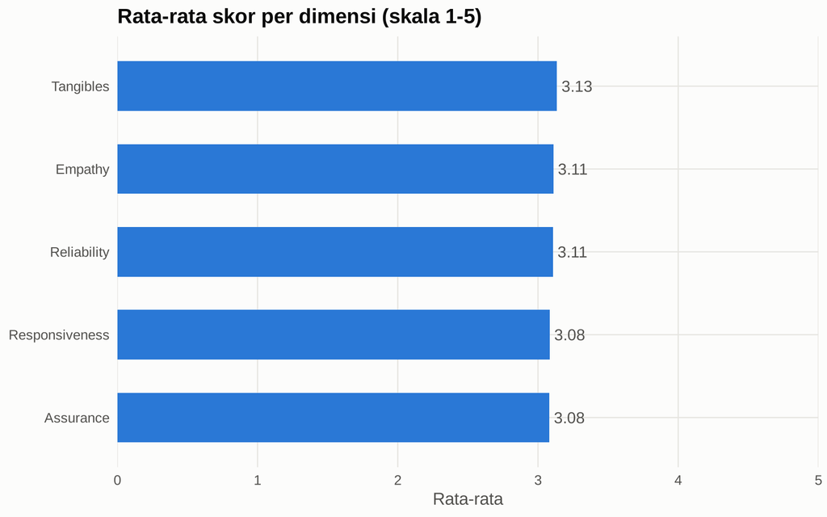

Rata-rata skor per dimensi SERVQUAL

```r
dim_mean <- item_desc %>% group_by(dimensi) %>%
  summarise(mean = mean(mean), .groups = "drop") %>% arrange(mean)
p_dim <- ggplot(dim_mean, aes(x = mean, y = reorder(dimensi, mean))) +
  geom_col(fill = pal_kategori()[1], width = 0.6) +
  geom_text(aes(label = sprintf("%.2f", mean)), hjust = -0.15, colour = "#52514e") +
  scale_x_continuous(limits = c(0, 5), expand = c(0, 0)) +
  labs(title = "Rata-rata skor per dimensi (skala 1-5)", x = "Rata-rata", y = NULL) +
  theme_portofolio()
p_dim
```

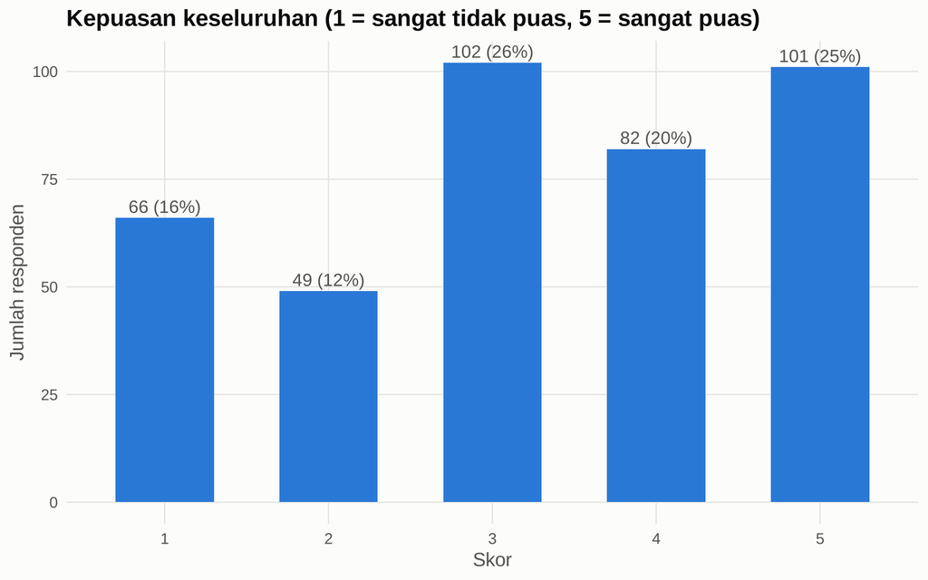

Distribusi kepuasan keseluruhan

```r
overall_tbl <- survey %>% count(overall_satisfaction) %>%
  mutate(pct = 100 * n / sum(n))
ggplot(overall_tbl, aes(factor(overall_satisfaction), n)) +
  geom_col(fill = pal_kategori()[1], width = 0.6) +
  geom_text(aes(label = sprintf("%d (%.0f%%)", n, pct)), vjust = -0.4, colour = "#52514e") +
  labs(title = "Kepuasan keseluruhan (1 = sangat tidak puas, 5 = sangat puas)",
       x = "Skor", y = "Jumlah responden") +
  theme_portofolio()
```

## 3. Uji validitas item (korelasi item-total terkoreksi)

Setiap item dikorelasikan dengan **jumlah item lain pada dimensinya**. Kriteria: r ≥ 0,30 dianggap valid (Nunnally & Bernstein). Sebagai pembanding, r-tabel untuk n = 400 pada α = 5% adalah 0.098.

```r
validity <- bind_rows(lapply(unique(map_dimension(items)), function(d) {
  cols <- items[map_dimension(items) == d]
  item_total_correlation(survey[, cols]) %>% mutate(dimensi = d, .before = 1)
}))
validity_fmt <- validity %>%
  mutate(r_item_total = round(r_item_total, 3),
         alpha_if_deleted = round(alpha_if_deleted, 3),
         keterangan = ifelse(valid, "Valid", "Tidak valid (r < 0,30)"))
knitr::kable(validity_fmt %>% dplyr::select(-valid),
             caption = "Korelasi item-total terkoreksi dan alpha jika item dihapus")
```

Korelasi item-total terkoreksi dan alpha jika item dihapus

| dimensi | item | r_item_total | alpha_if_deleted | keterangan |
| --- | --- | --- | --- | --- |
| Tangibles | tan_1 | 0.556 | 0.703 | Valid |
| Tangibles | tan_2 | 0.642 | 0.653 | Valid |
| Tangibles | tan_3 | 0.539 | 0.712 | Valid |
| Tangibles | tan_4 | 0.491 | 0.736 | Valid |
| Reliability | rel_1 | 0.696 | 0.773 | Valid |
| Reliability | rel_2 | 0.682 | 0.780 | Valid |
| Reliability | rel_3 | 0.680 | 0.780 | Valid |
| Reliability | rel_4 | 0.590 | 0.820 | Valid |
| Responsiveness | res_1 | 0.655 | 0.761 | Valid |
| Responsiveness | res_2 | 0.655 | 0.761 | Valid |
| Responsiveness | res_3 | 0.631 | 0.773 | Valid |
| Responsiveness | res_4 | 0.610 | 0.782 | Valid |
| Assurance | ass_1 | 0.537 | 0.604 | Valid |
| Assurance | ass_2 | 0.512 | 0.619 | Valid |
| Assurance | ass_3 | 0.447 | 0.660 | Valid |
| Assurance | ass_4 | 0.446 | 0.661 | Valid |
| Empathy | emp_1 | 0.545 | 0.497 | Valid |
| Empathy | emp_2 | 0.504 | 0.534 | Valid |
| Empathy | emp_3 | 0.412 | 0.595 | Valid |
| Empathy | emp_4 | 0.280 | 0.684 | Tidak valid (r < 0,30) |

```r
item_lemah <- validity$item[!validity$valid]
item_lemah_txt <- if (length(item_lemah)) paste(item_lemah, collapse = ", ") else "tidak ada"
```

**Temuan:** 1 item tidak memenuhi ambang, yaitu **emp_4**. Item ini memang disimulasikan dengan loading rendah (0,35), sehingga prosedur berhasil mendeteksinya.

## 4. Uji reliabilitas (Cronbach’s alpha)

Alpha dihitung dua cara: rumus manual (`cronbach_alpha()`, diuji di `tests/`) dan `psych::alpha()` sebagai verifikasi silang.

```r
alpha_tbl <- bind_rows(lapply(unique(map_dimension(items)), function(d) {
  cols <- items[map_dimension(items) == d]
  data.frame(
    dimensi      = d,
    n_item       = length(cols),
    alpha_manual = cronbach_alpha(survey[, cols]),
    alpha_psych  = psych::alpha(survey[, cols])$total$raw_alpha
  )
})) %>% mutate(interpretasi = as.character(interpret_alpha(alpha_manual)))
knitr::kable(alpha_tbl %>% mutate(across(starts_with("alpha"), ~ round(.x, 3))),
             caption = "Cronbach's alpha per dimensi (manual vs psych)")
```

Cronbach’s alpha per dimensi (manual vs psych)

| dimensi | n_item | alpha_manual | alpha_psych | interpretasi |
| --- | --- | --- | --- | --- |
| Tangibles | 4 | 0.759 | 0.759 | Dapat diterima |
| Reliability | 4 | 0.833 | 0.833 | Baik |
| Responsiveness | 4 | 0.816 | 0.816 | Baik |
| Assurance | 4 | 0.700 | 0.700 | Dapat diterima |
| Empathy | 4 | 0.650 | 0.650 | Dipertanyakan |

```r
stopifnot(all(abs(alpha_tbl$alpha_manual - alpha_tbl$alpha_psych) < 1e-8))

# Alpha seluruh instrumen (20 item) sebagai informasi tambahan
alpha_total <- cronbach_alpha(survey[, items])
```

Alpha keseluruhan 20 item = **0.864**. Alpha Empathy bila `emp_4` dihapus = **0.684** (vs 0.65 dengan item tersebut).

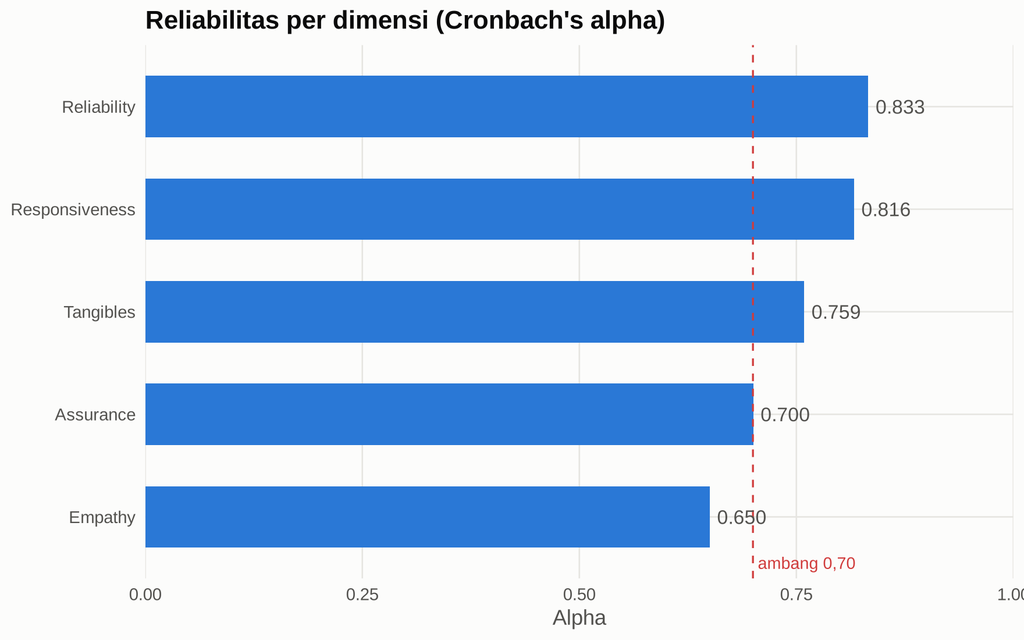

Cronbach’s alpha per dimensi

```r
p_alpha <- ggplot(alpha_tbl, aes(x = alpha_manual, y = reorder(dimensi, alpha_manual))) +
  geom_col(fill = pal_kategori()[1], width = 0.6) +
  geom_vline(xintercept = 0.7, linetype = "dashed", colour = pal_status()["critical"]) +
  geom_text(aes(label = sprintf("%.3f", alpha_manual)), hjust = -0.15, colour = "#52514e") +
  annotate("text", x = 0.7, y = 0.55, label = "ambang 0,70", hjust = -0.05,
           colour = pal_status()["critical"], size = 3.3) +
  scale_x_continuous(limits = c(0, 1), expand = c(0, 0)) +
  labs(title = "Reliabilitas per dimensi (Cronbach's alpha)", x = "Alpha", y = NULL) +
  theme_portofolio()
p_alpha
```

```r
simpan_grafik(p_alpha, "01_alpha_per_dimensi")
```

## 5. Kelayakan analisis faktor: KMO dan Bartlett

```r
R <- cor(survey[, items])
kmo      <- psych::KMO(R)
bartlett <- psych::cortest.bartlett(R, n = nrow(survey))
kmo_low  <- names(kmo$MSAi)[kmo$MSAi < 0.5]
```

| Uji | Statistik | Keputusan |
| --- | --- | --- |
| KMO (overall MSA) | 0.876 | Sangat layak (>= 0,80) |
| Bartlett’s test of sphericity | χ² = 2463.3, df = 190, p < 0,001 | Matriks korelasi bukan identitas → analisis faktor layak |

Item dengan MSA individual < 0,5: tidak ada.

## 6. Analisis faktor eksploratori (EFA)

### 6.1 Jumlah faktor

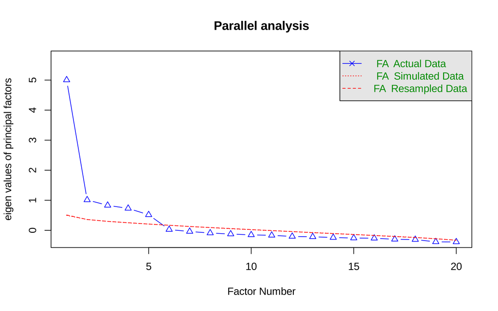

Parallel analysis untuk menentukan jumlah faktor

```
## Parallel analysis suggests that the number of factors =  5  and the number of components =  NA
```

```r
pa <- psych::fa.parallel(survey[, items], fm = "minres", fa = "fa",
                         n.iter = 50, plot = TRUE, main = "Parallel analysis")
```

Parallel analysis menyarankan **5 faktor**, sejalan dengan teori SERVQUAL.

### 6.2 Ekstraksi dan rotasi

Metode ekstraksi *minimum residual* (minres) dengan rotasi oblik **oblimin**, karena dimensi layanan diharapkan saling berkorelasi.

```r
efa <- psych::fa(survey[, items], nfactors = 5, rotate = "oblimin", fm = "minres")
load_tbl <- as.data.frame(unclass(efa$loadings)) %>%
  mutate(item = rownames(.), dimensi_teori = map_dimension(item), .before = 1)
load_fmt <- load_tbl %>%
  mutate(across(where(is.numeric), ~ ifelse(abs(.x) < 0.30, "", sprintf("%.2f", .x))))
knitr::kable(load_fmt, caption = "Loading faktor setelah rotasi oblimin (|loading| < 0,30 disembunyikan)")
```

Loading faktor setelah rotasi oblimin (|loading| < 0,30 disembunyikan)

|  | item | dimensi_teori | MR1 | MR2 | MR3 | MR4 | MR5 |
| --- | --- | --- | --- | --- | --- | --- | --- |
| tan_1 | tan_1 | Tangibles |  |  | 0.58 |  |  |
| tan_2 | tan_2 | Tangibles |  |  | 0.81 |  |  |
| tan_3 | tan_3 | Tangibles |  |  | 0.60 |  |  |
| tan_4 | tan_4 | Tangibles |  |  | 0.55 |  |  |
| rel_1 | rel_1 | Reliability | 0.77 |  |  |  |  |
| rel_2 | rel_2 | Reliability | 0.74 |  |  |  |  |
| rel_3 | rel_3 | Reliability | 0.79 |  |  |  |  |
| rel_4 | rel_4 | Reliability | 0.61 |  |  |  |  |
| res_1 | res_1 | Responsiveness |  | 0.72 |  |  |  |
| res_2 | res_2 | Responsiveness |  | 0.73 |  |  |  |
| res_3 | res_3 | Responsiveness |  | 0.70 |  |  |  |
| res_4 | res_4 | Responsiveness |  | 0.70 |  |  |  |
| ass_1 | ass_1 | Assurance |  |  |  | 0.65 |  |
| ass_2 | ass_2 | Assurance |  |  |  | 0.66 |  |
| ass_3 | ass_3 | Assurance |  |  |  | 0.51 |  |
| ass_4 | ass_4 | Assurance |  |  |  | 0.53 |  |
| emp_1 | emp_1 | Empathy |  |  |  |  | 0.71 |
| emp_2 | emp_2 | Empathy |  |  |  |  | 0.62 |
| emp_3 | emp_3 | Empathy |  |  |  |  | 0.47 |
| emp_4 | emp_4 | Empathy |  |  |  |  | 0.41 |

```r
cat(sprintf("Varians yang dijelaskan 5 faktor: %.1f%%\nRMSR = %.3f, TLI = %.3f, RMSEA = %.3f\n",
            100 * sum(efa$Vaccounted["Proportion Var", ]), efa$rms, efa$TLI, efa$RMSEA[1]))
```

```
## Varians yang dijelaskan 5 faktor: 46.0%
## RMSR = 0.020, TLI = 0.998, RMSEA = 0.008
```

```r
# Cek: apakah faktor dominan tiap item sesuai dimensi teoretis?
dominant <- apply(abs(efa$loadings), 1, which.max)
cross <- table(teori = load_tbl$dimensi_teori, faktor = colnames(efa$loadings)[dominant])
cross
```

```
##                 faktor
## teori            MR1 MR2 MR3 MR4 MR5
##   Assurance        0   0   0   4   0
##   Empathy          0   0   0   0   4
##   Reliability      4   0   0   0   0
##   Responsiveness   0   4   0   0   0
##   Tangibles        0   0   4   0   0
```

```r
kesesuaian <- mean(apply(cross, 1, max)) / 4 * 100
```

## 7. Regresi logistik ordinal: faktor penentu kepuasan keseluruhan

Variabel respons `overall_satisfaction` (1–5, ordinal) dimodelkan dengan *proportional odds model* (`MASS::polr`) terhadap skor rata-rata lima dimensi (item `emp_4` dikeluarkan karena tidak valid).

```r
items_valid <- setdiff(items, item_lemah)
scores <- dimension_scores(survey, items_valid)
model_df <- cbind(scores, overall = factor(survey$overall_satisfaction, ordered = TRUE))
fit <- MASS::polr(overall ~ Tangibles + Reliability + Responsiveness + Assurance + Empathy,
                  data = model_df, Hess = TRUE, method = "logistic")
fit_null <- MASS::polr(overall ~ 1, data = model_df, Hess = TRUE)
or_tbl <- odds_ratio_table(fit)
knitr::kable(or_tbl %>% mutate(across(where(is.numeric), ~ round(.x, 3))),
             caption = "Koefisien, odds ratio, dan IK 95%")
```

Koefisien, odds ratio, dan IK 95%

| term | estimate | odds_ratio | ci_lower | ci_upper | p_value |
| --- | --- | --- | --- | --- | --- |
| Tangibles | 0.674 | 1.962 | 1.406 | 2.738 | 0 |
| Reliability | 2.100 | 8.170 | 5.685 | 11.742 | 0 |
| Responsiveness | 1.492 | 4.448 | 3.189 | 6.204 | 0 |
| Assurance | 0.840 | 2.316 | 1.655 | 3.242 | 0 |
| Empathy | 0.914 | 2.494 | 1.827 | 3.404 | 0 |

```r
lr <- anova(fit_null, fit)
mcfadden <- 1 - as.numeric(logLik(fit)) / as.numeric(logLik(fit_null))
```

- Uji rasio kemungkinan model vs model nol: χ² = 506.8, df = 5, p < 0,001.
- Pseudo-R² McFadden = 0.402.

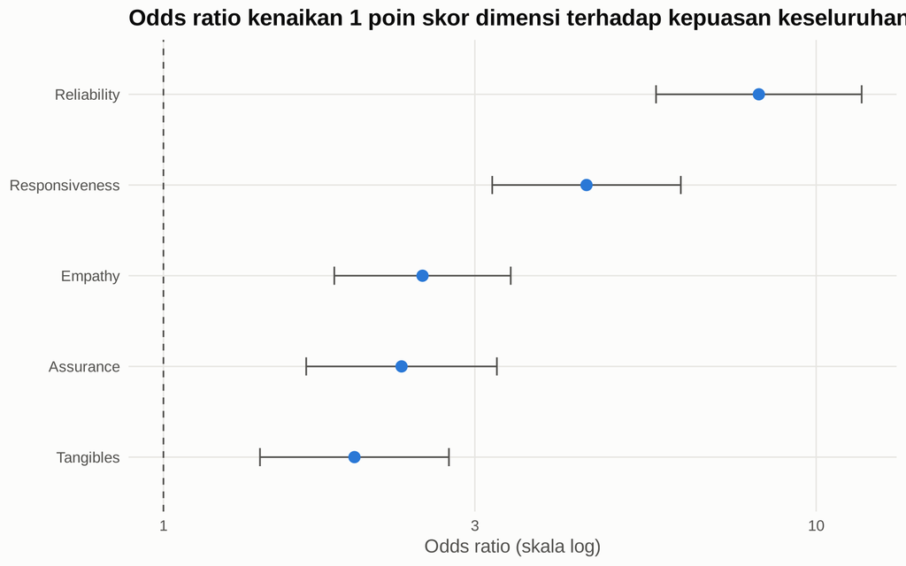

Odds ratio per dimensi (IK 95%)

```r
ggplot(or_tbl, aes(x = odds_ratio, y = reorder(term, odds_ratio))) +
  geom_vline(xintercept = 1, linetype = "dashed", colour = "#52514e") +
  geom_errorbarh(aes(xmin = ci_lower, xmax = ci_upper), height = 0.2, colour = "#52514e") +
  geom_point(size = 3, colour = pal_kategori()[1]) +
  scale_x_log10() +
  labs(title = "Odds ratio kenaikan 1 poin skor dimensi terhadap kepuasan keseluruhan",
       x = "Odds ratio (skala log)", y = NULL) +
  theme_portofolio()
```

### 7.1 Interpretasi odds ratio

```r
or_sorted <- or_tbl %>% arrange(desc(odds_ratio))
for (i in seq_len(nrow(or_sorted))) {
  r <- or_sorted[i, ]
  cat(sprintf("- **%s**: OR = %.2f (IK 95%%: %.2f–%.2f), p %s. Kenaikan 1 poin skor %s %s odds berada pada kategori kepuasan yang lebih tinggi sebesar %.0f%%%s.\n",
              r$term, r$odds_ratio, r$ci_lower, r$ci_upper,
              ifelse(r$p_value < 0.001, "< 0,001", paste("=", signif(r$p_value, 2))),
              r$term, ifelse(r$odds_ratio > 1, "meningkatkan", "menurunkan"),
              abs(r$odds_ratio - 1) * 100,
              ifelse(r$p_value < 0.05, "", " (tidak signifikan pada 5%)")))
}
```

- **Reliability**: OR = 8.17 (IK 95%: 5.68–11.74), p < 0,001. Kenaikan 1 poin skor Reliability meningkatkan odds berada pada kategori kepuasan yang lebih tinggi sebesar 717%.
- **Responsiveness**: OR = 4.45 (IK 95%: 3.19–6.20), p < 0,001. Kenaikan 1 poin skor Responsiveness meningkatkan odds berada pada kategori kepuasan yang lebih tinggi sebesar 345%.
- **Empathy**: OR = 2.49 (IK 95%: 1.83–3.40), p < 0,001. Kenaikan 1 poin skor Empathy meningkatkan odds berada pada kategori kepuasan yang lebih tinggi sebesar 149%.
- **Assurance**: OR = 2.32 (IK 95%: 1.65–3.24), p < 0,001. Kenaikan 1 poin skor Assurance meningkatkan odds berada pada kategori kepuasan yang lebih tinggi sebesar 132%.
- **Tangibles**: OR = 1.96 (IK 95%: 1.41–2.74), p < 0,001. Kenaikan 1 poin skor Tangibles meningkatkan odds berada pada kategori kepuasan yang lebih tinggi sebesar 96%.

### 7.2 Pemeriksaan asumsi proportional odds

Asumsi diperiksa secara informal dengan membandingkan koefisien regresi logistik biner pada setiap titik potong respons (Harrell, 2015): jika asumsi terpenuhi, koefisien tiap prediktor relatif stabil antar titik potong.

```r
cutpoints <- 2:5
po_check <- sapply(cutpoints, function(k) {
  y <- as.integer(survey$overall_satisfaction >= k)
  coef(glm(y ~ ., data = cbind(scores, y = y), family = binomial))[-1]
})
colnames(po_check) <- paste0("Y>=", cutpoints)
knitr::kable(round(po_check, 2), caption = "Koefisien logit biner per titik potong (idealnya mirip antar kolom)")
```

Koefisien logit biner per titik potong (idealnya mirip antar kolom)

|  | Y>=2 | Y>=3 | Y>=4 | Y>=5 |
| --- | --- | --- | --- | --- |
| Tangibles | 0.36 | 0.66 | 0.82 | 0.98 |
| Reliability | 2.80 | 2.55 | 2.01 | 1.89 |
| Responsiveness | 1.45 | 1.69 | 1.49 | 1.48 |
| Assurance | 0.96 | 1.10 | 0.68 | 0.80 |
| Empathy | 1.20 | 0.42 | 1.05 | 0.96 |

## 8. Kesimpulan dan rekomendasi

1. **Instrumen reliabel**: alpha setiap dimensi berada pada rentang 0.65–0.833; dimensi terendah adalah Empathy, yang membaik setelah `emp_4` dihapus.
2. **Struktur 5 faktor terkonfirmasi** oleh parallel analysis dan EFA (KMO 0.88; 100% item memuat pada faktor yang sesuai teori).
3. **Prioritas perbaikan**: Reliability (OR 8.17) dan Responsiveness (OR 4.45) adalah pendorong terkuat kepuasan; tiap kenaikan 1 poin pada skor dimensi tersebut melipatgandakan odds pelanggan masuk kategori lebih puas. Manajemen sebaiknya memfokuskan sumber daya pada dua dimensi ini.
4. **Perbaikan instrumen**: revisi atau ganti item `emp_4` sebelum survei berikutnya.

### Padanan di SPSS / Minitab

Lihat `docs/padanan_spss_minitab.md`, misalnya alpha = *Analyze › Scale › Reliability Analysis* (SPSS) atau *Stat › Multivariate › Item Analysis* (Minitab).

```
## R4.3.3 | psych 2.4.1 | MASS 7.3.60.0.1
```